# proyecto_Series

Proyecto : **Pronostico de crecimiento de viajes realizados en colectivo en la ciudad de México.**

Alumno : *Ricardo De León*

*Objetivo:*

Se desea indentificar un modelo de pronostico con series de tiempo del crecimiento en los viajes hechos en la cuidad de México.

*Datos:*

El conjunto de datos es publica y fué obtenida de la pagina del INEGI https://datos.cdmx.gob.mx/group/movilidad

Nombre archivo : c_de_datos_mexico.csv

*Descripción*:

Columnas

- ANIO : Año : Int
- ID_MES : Mes : Int
- TRASPORTE : Tipo de transporte : Object
- VARIABLE : Pasajeros : Object
- ID_ENTIDAD : Entidad : Object
- ID_MUNICIPIO : Municipio : Int
- VALOR : Numero de Pasajeros : Int

General de Librerias

```python
!pip install pmdarima
!pip install skforecast
```

```python
# Librerias

import pandas as pd
import numpy as np
import matplotlib.pyplot as plt
plt.style.use('seaborn-v0_8-darkgrid')
from IPython.display import display
import seaborn as sns
from statsmodels.tsa.holtwinters import ExponentialSmoothing
from sklearn.metrics import mean_squared_error
from math import sqrt


# pmdarima
from pmdarima import ARIMA
from pmdarima import auto_arima

# statsmodels
from statsmodels.tsa.statespace.sarimax import SARIMAX
from statsmodels.tsa.stattools import adfuller
from statsmodels.tsa.stattools import kpss
from statsmodels.graphics.tsaplots import plot_acf, plot_pacf
from statsmodels.tsa.seasonal import seasonal_decompose

# skforecast
from skforecast.Sarimax import Sarimax
from skforecast.ForecasterSarimax import ForecasterSarimax
from skforecast.model_selection_sarimax import backtesting_sarimax
from skforecast.model_selection_sarimax import grid_search_sarimax
from sklearn.metrics import mean_absolute_error

import warnings
```

Conjunto de Datos

```python
# Leyendo el conjunto de datos

datos = pd.read_csv('c_de_datos_mexico.csv')
```

Tratamiento De Datos

```python
# unificación de columnas ANIO y ID_MES a FECHA y convertirla a al tipo de dato fecha

datos['FECHA'] = pd.to_datetime(datos.ANIO.astype(str) + '/' + datos.ID_MES.astype(str) + '/01')
datos.head(5)
```

|  | ANIO | ID_MES | TRANSPORTE | VARIABLE | ID_ENTIDAD | ID_MUNICIPIO | VALOR | FECHA |
| --- | --- | --- | --- | --- | --- | --- | --- | --- |
| 0 | 1986 | 1 | Sistema de Transporte Colectivo Metro | Pasajeros transportados | Ciudad de M√©xico | 999 | 110245300 | 1986-01-01 |
| 1 | 1986 | 2 | Sistema de Transporte Colectivo Metro | Pasajeros transportados | Ciudad de M√©xico | 999 | 98372400 | 1986-02-01 |
| 2 | 1986 | 3 | Sistema de Transporte Colectivo Metro | Pasajeros transportados | Ciudad de M√©xico | 999 | 103989500 | 1986-03-01 |
| 3 | 1986 | 4 | Sistema de Transporte Colectivo Metro | Pasajeros transportados | Ciudad de M√©xico | 999 | 112752000 | 1986-04-01 |
| 4 | 1986 | 5 | Sistema de Transporte Colectivo Metro | Pasajeros transportados | Ciudad de M√©xico | 999 | 118057300 | 1986-05-01 |

```python
# Verificando si existen nulos

print(f'Número de filas con missing values: {datos.isnull().any(axis=1).mean()}')
```

```
Número de filas con missing values: 0.0
```

```python
# Eliminación de columnas no necesarias y arreglo de dataset

datos = datos[['FECHA', 'VALOR']]
datos = datos.set_index('FECHA')
datos = datos.asfreq('MS') # Monthly start
# datos = datos['VALOR']
display(datos.head(4))
```

| FECHA | VALOR |
| --- | --- |
| 1986-01-01 | 110245300 |
| 1986-02-01 | 98372400 |
| 1986-03-01 | 103989500 |
| 1986-04-01 | 112752000 |

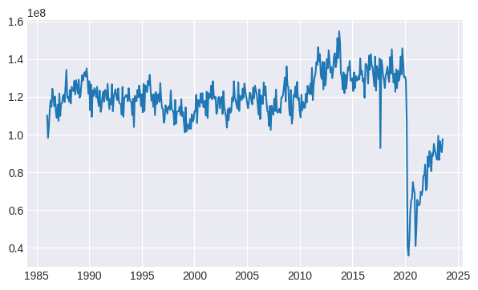

```python
# Graicando el conjunto de datos de series de tiempo

fig, ax = plt.subplots(figsize=(7, 4))
ax.plot(datos.index, datos['VALOR']);
```

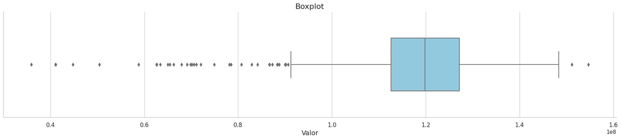

```python
# Diagrama de caja

# Estilo
sns.set(style="whitegrid")

# Seaborn
plt.figure(figsize=(23, 4))
ax = sns.boxplot(x=datos['VALOR'], color='skyblue', width=0.5)

# titulo y labels
plt.title('Boxplot', fontsize=16)
plt.xlabel('Valor', fontsize=14)
plt.tick_params(axis='both', labelsize=12)

# fondo blanco
ax.yaxis.grid(True, linestyle='--', alpha=0.7, color='white')

# remover spines
sns.despine()

# mostrar
plt.show()
```

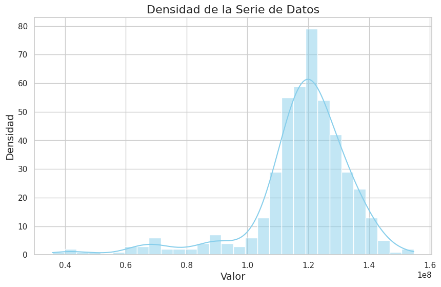

```python
# Observación de la densidad

# Crear un gráfico de densidad usando Seaborn
plt.figure(figsize=(10, 6))
sns.histplot(datos['VALOR'], kde=True, bins=30, color='skyblue')

# Agregar etiquetas y título
plt.title('Densidad de la Serie de Datos', fontsize=16)
plt.xlabel('Valor', fontsize=14)
plt.ylabel('Densidad', fontsize=14)

# Mostrar el gráfico
plt.show()
```

```python
# Elimionamos outliers

df = datos.copy()

# Calcular el rango intercuartílico (IQR)
Q1 = df['VALOR'].quantile(0.25)
Q3 = df['VALOR'].quantile(0.75)
IQR = Q3 - Q1

# Definir los límites para identificar outliers
lower_limit = Q1 - 1.5 * IQR
upper_limit = Q3 + 1.5 * IQR

# Filtrar los outliers
outliers = df[(df['VALOR'] < lower_limit) | (df['VALOR'] > upper_limit)]

# Imprimir los outliers
print("Outliers:")
print(outliers)

# Remover los outliers del DataFrame original
df_no_outliers = df[(df['VALOR'] >= lower_limit) & (df['VALOR'] <= upper_limit)]

# Imprimir el DataFrame sin outliers
print("\nDataFrame sin outliers:")
print(df_no_outliers)
```

```
Outliers:
                VALOR
FECHA
2013-08-01  151186639
2013-10-01  154718101
2020-04-01   41139457
2020-05-01   35899769
2020-06-01   44780955
2020-07-01   58756521
2020-08-01   65016011
2020-09-01   66219212
2020-10-01   74872132
2020-11-01   71089553
2020-12-01   69140763
2021-01-01   41033642
2021-02-01   50436321
2021-03-01   65449779
2021-04-01   62577359
2021-05-01   62689975
2021-06-01   63410819
2021-07-01   69822069
2021-08-01   67964499
2021-09-01   70154247
2021-10-01   78122952
2021-11-01   78483883
2021-12-01   84154004
2022-01-01   70563670
2022-02-01   72052555
2022-03-01   88358374
2022-04-01   82897274
2022-06-01   88424030
2022-07-01   80680662
2022-08-01   90184647
2022-09-01   88794502
2022-12-01   89981293
2023-01-01   87266174
2023-02-01   86696037
2023-04-01   86639757
2023-07-01   90692404

DataFrame sin outliers:
                VALOR
FECHA
1986-01-01  110245300
1986-02-01   98372400
1986-03-01  103989500
1986-04-01  112752000
1986-05-01  118057300
...               ...
2022-11-01   91831197
2023-03-01   99399033
2023-05-01   96485575
2023-06-01   92973425
2023-08-01   97667492

[416 rows x 1 columns]
```

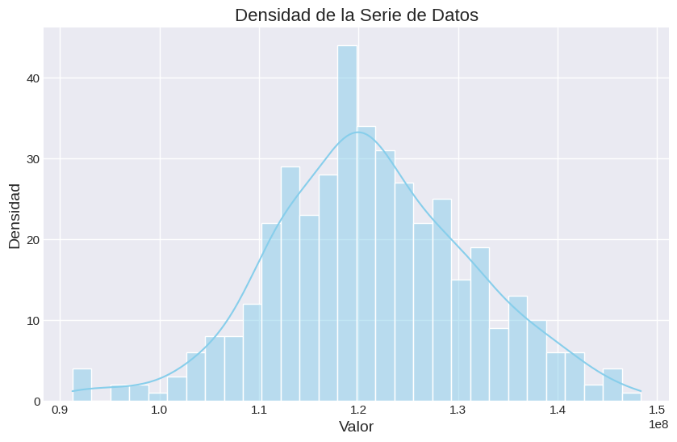

```python
# Observación de la densidad

# Crear un gráfico de densidad usando Seaborn
plt.figure(figsize=(10, 6))
sns.histplot(df_no_outliers['VALOR'], kde=True, bins=30, color='skyblue')

# Agregar etiquetas y título
plt.title('Densidad de la Serie de Datos', fontsize=16)
plt.xlabel('Valor', fontsize=14)
plt.ylabel('Densidad', fontsize=14)

# Mostrar el gráfico
plt.show()
```

```python
# Verificando si existen nulos

print(f'Número de filas con missing values: {df_no_outliers.isnull().any(axis=1).mean()}')
df_no_outliers.head(5)
```

```
Número de filas con missing values: 0.0
```

| FECHA | VALOR |
| --- | --- |
| 1986-01-01 | 110245300 |
| 1986-02-01 | 98372400 |
| 1986-03-01 | 103989500 |
| 1986-04-01 | 112752000 |
| 1986-05-01 | 118057300 |

```python
# Aplicar la transformación logarítmica a la columna 'VALOR'
from sklearn.preprocessing import MinMaxScaler

# Inicializar el escalador MinMax
scaler = MinMaxScaler()

# Aplicar la normalización a la columna 'value'
df_no_outliers['VALOR'] = scaler.fit_transform(df_no_outliers[['VALOR']])

df_no_outliers.head(5)
```

| FECHA | VALOR |
| --- | --- |
| 1986-01-01 | 0.332687 |
| 1986-02-01 | 0.124791 |
| 1986-03-01 | 0.223147 |
| 1986-04-01 | 0.376579 |
| 1986-05-01 | 0.469476 |

[figure not shown]

```python
# Observación de la densidad

# Crear un gráfico de densidad usando Seaborn
plt.figure(figsize=(10, 6))
sns.histplot(df_no_outliers, kde=True, bins=30, color='skyblue')

# Agregar etiquetas y título
plt.title('Densidad de la Serie de Datos', fontsize=16)
plt.xlabel('Valor', fontsize=14)
plt.ylabel('Densidad', fontsize=14)

# Mostrar el gráfico
plt.show()
```

Trabajamos solo con las columnas necesarias, usamos 'MS' monthly start para especificar que la fecuencia de la serie sea mensual

[output not shown]

[figure not shown]

```python
# Division de datos en Train y Test

steps = 36 # los últimos 3 años
datos_train = df_no_outliers[:-steps]
datos_test  = df_no_outliers[-steps:]

print(f"Fechas train : {datos_train.index.min()} --- {datos_train.index.max()}  (n={len(datos_train)})")
print(f"Fechas test  : {datos_test.index.min()} --- {datos_test.index.max()}  (n={len(datos_test)})")

fig, ax = plt.subplots(figsize=(6, 2.5))
datos_train.plot(ax=ax, label='train')
datos_test.plot(ax=ax, label='test')
ax.legend();
```

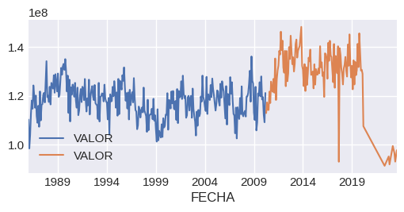

```python
# Dividir los datos en entrenamiento y prueba
train_size = int(len(df_no_outliers) * 0.7)
datos_train, datos_test = df_no_outliers.iloc[:train_size], df_no_outliers.iloc[train_size:]

fig, ax = plt.subplots(figsize=(6, 2.5))
datos_train.plot(ax=ax, label='train')
datos_test.plot(ax=ax, label='test')
ax.legend();
```

Descomposición de la serie

# ARIMA

**ARIMA** (AutoRegressive Integrated Moving Average) y **SARIMAX** (Seasonal AutoRegressive Integrated Moving Average with eXogenous regressors) son modelos estadísticos ampliamente reconocidos y utilizados para la predicción de series temporales (forecasting).

Este modelo consta de tres componentes. El elemento autorregresivo (**AR**) relaciona el valor actual con valores pasados (**lags**). El elemento de media móvil (**MA**) asume que el error de predicción es una combinación lineal de los errores de predicción pasados. Por último, el componente integrado (**I**) indica que los valores de la serie original han sido reemplazados por la diferencia entre valores consecutivos (y este proceso de diferencia puede haberse realizado más de una vez).

En la notación del modelo ARIMA-SARIMAX, los parámetros 𝑝, 𝑑, y 𝑞 representan las componentes autorregresivas, de diferenciación y de media móvil, respectivamente. 𝑃, 𝐷, y 𝑄 son las mismas componentes para la parte estacional del modelo y 𝑚 el número de períodos en cada temporada.

- 𝑝 es el orden (número de lags temporales) de la parte autorregresiva del modelo.
- 𝑑 es el grado de diferenciación (el número de veces que se han restado los valores consecutivos de la serie).
- 𝑞 es el tamaño de la media móvil del modelo.
- 𝑃 es el orden (número de lags temporales) de la parte estacional del modelo.
- 𝐷 es el grado de diferenciación de la parte estacional del modelo.
- 𝑄 es el tamaño de la media móvil de la parte estacional del modelo.
- 𝑚 indica al número de períodos en cada temporada.

Cuando los términos 𝑃, 𝐷, 𝑄, y 𝑚 son cero y no se incluyen variables exógenas, el modelo SARIMAX es equivalente a un ARIMA.

**Estacionariedad**: la estacionariedad significa que las propiedades estadísticas (media, varianza...) permanecen constantes a lo largo del tiempo, por lo que las series temporales con tendencias o estacionalidad no son estacionarias. Dado que ARIMA presupone la estacionariedad de los datos, es esencial someterlos a pruebas rigurosas, como la prueba Dickey-Fuller aumentada, para evaluar que se cumple. Si se constata la no estacionariedad, las series deben diferenciarse hasta alcanzar la estacionariedad. Este análisis ayuda a determinar el valor óptimo del parámetro 𝑑.

**Análisis de autocorrelación**: Graficar las funciones de autocorrelación y autocorrelación parcial (ACF y PACF) para identificar posibles relaciones de rezago (lags) entre los valores de la serie. Este análisis visual ayuda a determinar los términos autorregresivos (AR) y de media móvil (MA) adecuados ( 𝑝 y 𝑞 ) para el modelo ARIMA.

**Descomposición estacional:** en los casos donde se sospecha de estacionalidad, descomponer la serie en componentes de tendencia, estacionales y residuales utilizando técnicas como las medias móviles la descomposición estacional de series temporales (STL) puede revelar patrones ocultos y ayudar a identificar la estacionalidad. Este análisis ayuda a determinar los valores óptimos de los parámetros 𝑃, 𝐷, 𝑄 y 𝑚.

Al parecer la **tendencia** antes de la pandemia tendia ligeramente positiva, después de la pandemia volvio nuevamente la tendencia a la alta.

```
Test estacionariedad para serie diferenciada (order=1)
--------------------------------------------------
ADF Statistic: -4.508489109899286, p-value: 0.00018981013658506788
KPSS Statistic: 0.10197777651218363, p-value: 0.1

Test estacionariedad para serie diferenciada (order=2)
--------------------------------------------------
ADF Statistic: -8.393338773042512, p-value: 2.3345137425952635e-13
KPSS Statistic: 0.02529756100609631, p-value: 0.1
```

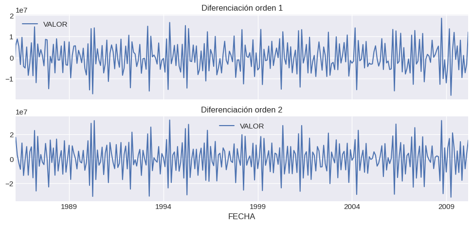

```python
# Test estacionariedad
# ==============================================================================
warnings.filterwarnings("ignore")

datos_diff_1 = datos_train.diff().dropna()
datos_diff_2 = datos_diff_1.diff().dropna()

print('\nTest estacionariedad para serie diferenciada (order=1)')
print('--------------------------------------------------')
adfuller_result = adfuller(datos_diff_1)
kpss_result = kpss(df_no_outliers.diff().dropna())
print(f'ADF Statistic: {adfuller_result[0]}, p-value: {adfuller_result[1]}')
print(f'KPSS Statistic: {kpss_result[0]}, p-value: {kpss_result[1]}')

print('\nTest estacionariedad para serie diferenciada (order=2)')
print('--------------------------------------------------')
adfuller_result = adfuller(datos_diff_2)
kpss_result = kpss(df_no_outliers.diff().diff().dropna())
print(f'ADF Statistic: {adfuller_result[0]}, p-value: {adfuller_result[1]}')
print(f'KPSS Statistic: {kpss_result[0]}, p-value: {kpss_result[1]}')

warnings.filterwarnings("default")

# Gráfico series
# ==============================================================================
fig, axs = plt.subplots(nrows=2, ncols=1, figsize=(12, 5), sharex=True)
datos_diff_1.plot(ax=axs[0], title='Diferenciación orden 1')
datos_diff_2.plot(ax=axs[1], title='Diferenciación orden 2');
```

- La prueba KPSS se centra en la presencia de tendencias. Un p-value bajo indica la no estacionariedad debida a una tendencia.
- La prueba ADF se centra en la presencia de una raíz unitari. Un p-value bajo indica que la serie temporal no tiene una raíz unitaria, lo que sugiere que podría ser estacionaria

# Análisis de autocorrelación

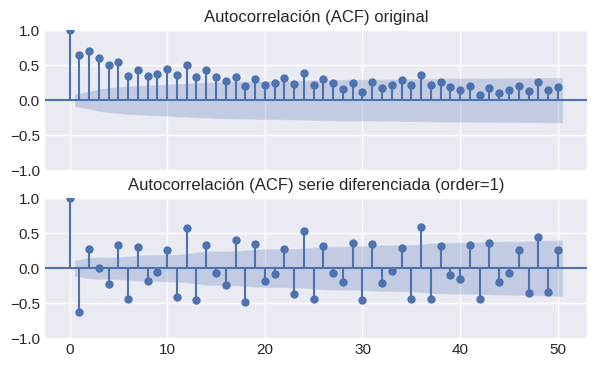

```python
# Gráfica de la autocorrelación ACF

fig, axs = plt.subplots(nrows=2, ncols=1, figsize=(7, 4), sharex=True)
plot_acf(df_no_outliers['VALOR'], ax=axs[0], lags=50, alpha=0.05)
axs[0].set_title('Autocorrelación (ACF) original')
plot_acf(datos_diff_1, ax=axs[1], lags=50, alpha=0.05)
axs[1].set_title('Autocorrelación (ACF) serie diferenciada (order=1)');
```

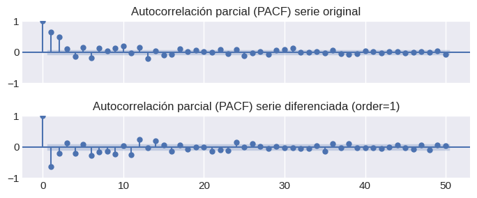

```python
# Autocorrelación parcial PACF

fig, axs = plt.subplots(nrows=2, ncols=1, figsize=(7, 3), sharex=True)
plot_pacf(df_no_outliers, ax=axs[0], lags=50, alpha=0.05)
axs[0].set_title('Autocorrelación parcial (PACF) serie original')
plot_pacf(datos_diff_1, ax=axs[1], lags=50, alpha=0.05)
axs[1].set_title('Autocorrelación parcial (PACF) serie diferenciada (order=1)');
plt.tight_layout();
```

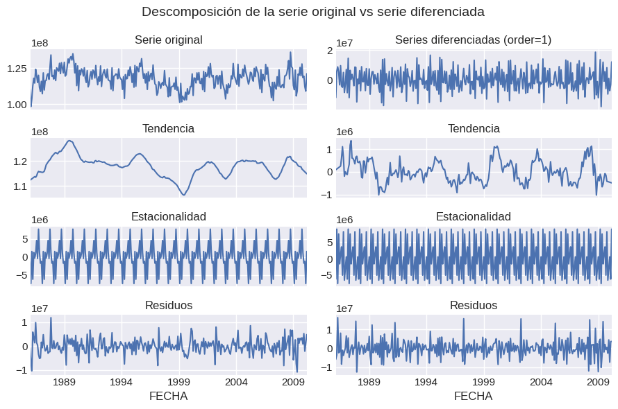

```python
res_decompose = seasonal_decompose(datos_train, model='additive', extrapolate_trend='freq')
res_descompose_diff_2 = seasonal_decompose(datos_diff_1, model='additive', extrapolate_trend='freq')

fig, axs = plt.subplots(nrows=4, ncols=2, figsize=(9, 6), sharex=True)
res_decompose.observed.plot(ax=axs[0, 0])
axs[0, 0].set_title('Serie original')
res_decompose.trend.plot(ax=axs[1, 0])
axs[1, 0].set_title('Tendencia')
res_decompose.seasonal.plot(ax=axs[2, 0])
axs[2, 0].set_title('Estacionalidad')
res_decompose.resid.plot(ax=axs[3, 0])
axs[3, 0].set_title('Residuos')
res_descompose_diff_2.observed.plot(ax=axs[0, 1])
axs[0, 1].set_title('Series diferenciadas (order=1)')
res_descompose_diff_2.trend.plot(ax=axs[1, 1])
axs[1, 1].set_title('Tendencia')
res_descompose_diff_2.seasonal.plot(ax=axs[2, 1])
axs[2, 1].set_title('Estacionalidad')
res_descompose_diff_2.resid.plot(ax=axs[3, 1])
axs[3, 1].set_title('Residuos')
fig.suptitle('Descomposición de la serie original vs serie diferenciada', fontsize=14)
fig.tight_layout();
```

Al parecer se presenta una estacionalidad Anual

```python
# Modelo SARIMAX con statsmodels.Sarimax
# ==============================================================================
warnings.filterwarnings("ignore", category=UserWarning, message='Non-invertible|Non-stationary')
modelo = SARIMAX(endog = datos_train, order = (2, 1, 1), seasonal_order = (1, 1, 1, 12))
modelo_res = modelo.fit(disp=0)
warnings.filterwarnings("default")
print(modelo_res.summary())


#%%
# Predicción
# ==============================================================================
predicciones_statsmodels = modelo_res.get_forecast(steps=len(datos_test)).predicted_mean
predicciones_statsmodels.name = 'predicciones_statsmodels'
display(predicciones_statsmodels.head(4))

# Error test
# ==============================================================================
error_mse = mean_squared_error(y_true = datos_test, y_pred = predicciones_statsmodels)
print(f"Error de test (mse) {error_mse}")
```

```
                                     SARIMAX Results
==========================================================================================
Dep. Variable:                              VALOR   No. Observations:                  291
Model:             SARIMAX(2, 1, 1)x(1, 1, 1, 12)   Log Likelihood               -4692.625
Date:                            Wed, 15 Nov 2023   AIC                           9397.250
Time:                                    22:23:05   BIC                           9419.015
Sample:                                01-01-1986   HQIC                          9405.982
                                     - 03-01-2010
Covariance Type:                              opg
==============================================================================
                 coef    std err          z      P>|z|      [0.025      0.975]
------------------------------------------------------------------------------
ar.L1         -0.6405      0.248     -2.583      0.010      -1.127      -0.154
ar.L2         -0.2439      0.058     -4.193      0.000      -0.358      -0.130
ma.L1          0.3670      0.243      1.510      0.131      -0.109       0.843
ar.S.L12       0.3357      0.032     10.539      0.000       0.273       0.398
ma.S.L12      -0.8033      0.045    -17.824      0.000      -0.892      -0.715
sigma2      2.679e+13   5.26e-15   5.09e+27      0.000    2.68e+13    2.68e+13
===================================================================================
Ljung-Box (L1) (Q):                  15.97   Jarque-Bera (JB):               108.49
Prob(Q):                              0.00   Prob(JB):                         0.00
Heteroskedasticity (H):               0.65   Skew:                            -0.25
Prob(H) (two-sided):                  0.04   Kurtosis:                         6.02
===================================================================================

Warnings:
[1] Covariance matrix calculated using the outer product of gradients (complex-step).
[2] Covariance matrix is singular or near-singular, with condition number 9.08e+43. Standard errors may be unstable.
```

```
2010-04-01    1.086063e+08
2010-05-01    1.134620e+08
2010-06-01    1.190076e+08
2010-07-01    1.186274e+08
Freq: MS, Name: predicciones_statsmodels, dtype: float64
```

```
Error de test (mse) 254757826338906.38
```

```python
# Modelo SARIMAX con skforecast.Sarimax
# ==============================================================================
warnings.filterwarnings("ignore", category=UserWarning, message='Non-invertible|Non-stationary')
modelo = Sarimax(order=(2, 1, 1), seasonal_order=(1, 1, 1, 12))
modelo.fit(y=datos_train)
print(modelo.summary())
warnings.filterwarnings("default")

#%%

# Predictión
# ==============================================================================
predicciones_skforecast = modelo.predict(steps=len(datos_test))
display(predicciones_skforecast.head(4))

# Error test
# ==============================================================================
error_mse = mean_squared_error(y_true = datos_test, y_pred = predicciones_skforecast)
print(f"Error de test (mse) {error_mse}")
```

```
                                     SARIMAX Results
==========================================================================================
Dep. Variable:                              VALOR   No. Observations:                  291
Model:             SARIMAX(2, 1, 1)x(1, 1, 1, 12)   Log Likelihood               -4692.625
Date:                            Wed, 15 Nov 2023   AIC                           9397.250
Time:                                    22:23:17   BIC                           9419.015
Sample:                                01-01-1986   HQIC                          9405.982
                                     - 03-01-2010
Covariance Type:                              opg
==============================================================================
                 coef    std err          z      P>|z|      [0.025      0.975]
------------------------------------------------------------------------------
ar.L1         -0.6405      0.248     -2.583      0.010      -1.127      -0.154
ar.L2         -0.2439      0.058     -4.193      0.000      -0.358      -0.130
ma.L1          0.3670      0.243      1.510      0.131      -0.109       0.843
ar.S.L12       0.3357      0.032     10.539      0.000       0.273       0.398
ma.S.L12      -0.8033      0.045    -17.824      0.000      -0.892      -0.715
sigma2      2.679e+13   5.26e-15   5.09e+27      0.000    2.68e+13    2.68e+13
===================================================================================
Ljung-Box (L1) (Q):                  15.97   Jarque-Bera (JB):               108.49
Prob(Q):                              0.00   Prob(JB):                         0.00
Heteroskedasticity (H):               0.65   Skew:                            -0.25
Prob(H) (two-sided):                  0.04   Kurtosis:                         6.02
===================================================================================

Warnings:
[1] Covariance matrix calculated using the outer product of gradients (complex-step).
[2] Covariance matrix is singular or near-singular, with condition number 9.08e+43. Standard errors may be unstable.
```

|  | pred |
| --- | --- |
| 2010-04-01 | 1.086063e+08 |
| 2010-05-01 | 1.134620e+08 |
| 2010-06-01 | 1.190076e+08 |
| 2010-07-01 | 1.186274e+08 |

```
Error de test (mse) 254757826338906.38
```

# ETS

El algoritmo **ETS** es especialmente útil para conjuntos de datos con estacionalidad y otras suposiciones previas sobre los datos. ETS calcula un promedio ponderado sobre todas las observaciones en el conjunto de datos de las series temporales de entrada como su predicción. Las ponderaciones disminuyen exponencialmente con el tiempo, en lugar de las ponderaciones constantes en los métodos de promedio móvil simple. Las ponderaciones dependen de un parámetro constante, conocido como parámetro de suavizamiento.

```
                        ExponentialSmoothing Model Results
==================================================================================
Dep. Variable:                    VALOR   No. Observations:                    291
Model:             ExponentialSmoothing   SSE                 4570411230968715.000
Optimized:                         True   AIC                             8870.051
Trend:                             None   BIC                             8921.478
Seasonal:                      Additive   AICC                            8872.037
Seasonal Periods:                    12   Date:                   Wed, 15 Nov 2023
Box-Cox:                          False   Time:                           22:41:15
Box-Cox Coeff.:                    None
=================================================================================
                          coeff                 code              optimized
---------------------------------------------------------------------------------
smoothing_level               0.3585714                alpha                 True
smoothing_seasonal            0.1131933                gamma                 True
initial_level                1.1411e+08                  l.0                 True
initial_seasons.0            1.0913e+06                  s.0                 True
initial_seasons.1           -7.9685e+06                  s.1                 True
initial_seasons.2            8.0034e+05                  s.2                 True
initial_seasons.3           -7.0403e+06                  s.3                 True
initial_seasons.4            1.5538e+06                  s.4                 True
initial_seasons.5           -2.5348e+05                  s.5                 True
initial_seasons.6            3.7944e+06                  s.6                 True
initial_seasons.7            4.2584e+06                  s.7                 True
initial_seasons.8           -7.5886e+05                  s.8                 True
initial_seasons.9            5.4441e+06                  s.9                 True
initial_seasons.10           3.2792e+06                 s.10                 True
initial_seasons.11          -4.2003e+06                 s.11                 True
---------------------------------------------------------------------------------
```

```
1996-06-01    1.205194e+08
1996-07-01    1.213828e+08
1996-08-01    1.222995e+08
1996-09-01    1.179966e+08
Freq: MS, Name: predicciones_ets_fit, dtype: float64
```

```
Error de test (mse) 254757826338906.38
```

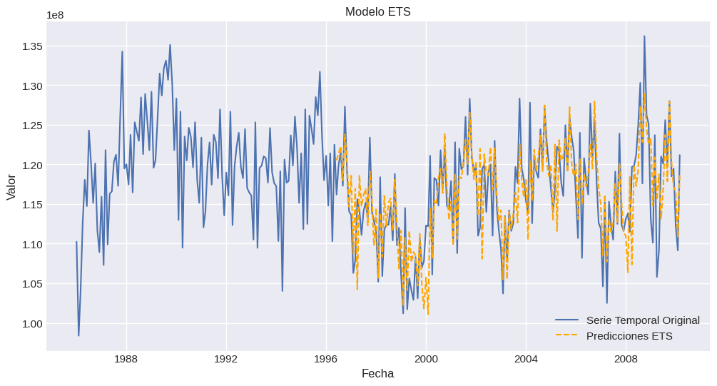

```python
# ExponentialSmoothing

ets_model = ExponentialSmoothing(datos_train, seasonal='add', seasonal_periods=12)
ets_fit = ets_model.fit()
print(ets_fit.summary())


# Prediction

predicciones_ets_fit = ets_fit.predict(len(datos_test))
predicciones_ets_fit.name = 'predicciones_ets_fit'
display(predicciones_ets_fit.head(4))

# Error test
# ==============================================================================
error_mse = mean_squared_error(y_true = datos_test, y_pred = predicciones_skforecast)
print(f"Error de test (mse) {error_mse}")

# Plotear la serie original y las predicciones
plt.figure(figsize=(12, 6))
plt.plot(datos_train, label='Serie Temporal Original')
plt.plot(predicciones_ets_fit.index, predicciones_ets_fit, label='Predicciones ETS', linestyle='--', color='orange')
plt.title('Modelo ETS')
plt.xlabel('Fecha')
plt.ylabel('Valor')
plt.legend()
plt.show()
```

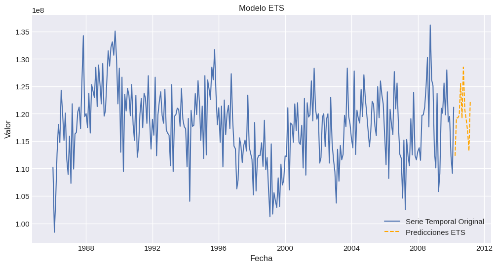

```python
from statsmodels.tsa.holtwinters import ExponentialSmoothing
# Ajustar un modelo ETS
model = ExponentialSmoothing(datos_train, trend='add', seasonal='add', seasonal_periods=12)
result = model.fit()

# Hacer predicciones
forecast = result.forecast(steps=12)

# Plotear la serie original y las predicciones
plt.figure(figsize=(12, 6))
plt.plot(datos_train, label='Serie Temporal Original')
plt.plot(forecast.index, forecast, label='Predicciones ETS', linestyle='--', color='orange')
plt.title('Modelo ETS')
plt.xlabel('Fecha')
plt.ylabel('Valor')
plt.legend()
plt.show()
```

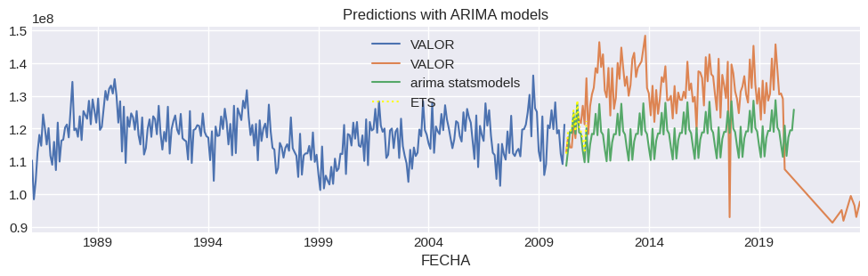

```python
# Plot predictions

fig, ax = plt.subplots(figsize=(12, 3))
datos_train.plot(ax=ax, label='train')
datos_test.plot(ax=ax, label='test')
predicciones_statsmodels.plot(ax=ax, label='arima statsmodels')
forecast.plot(ax=ax, label='ETS', linestyle='dotted', color='yellow')
ax.set_title('Predictions with ARIMA models')
ax.legend();
```